```python
# In your terminal:
# !pip install --upgrade --quiet networkx
# pip install rpy2
# pip install tzlocal

# On R:
# install.packages("BiocManager")
# BiocManager::install("graph")
# BiocManager::install("RBGL")
# BiocManager::install("Rgraphviz")
# install.packages("pcalg")

# install.packages("SMPracticals")
# install.packages("kpcalg")
# install.packages("gplots")
# install.packages("igraph")
```

```python
%load_ext rpy2.ipython
```

# Libraries Required:

```python
import numpy as np
import seaborn as sns
import networkx as nx
import matplotlib
import matplotlib.pyplot as plt
import statsmodels.api as sm
from collections import deque
from sklearn.preprocessing import scale
from sklearn.metrics import precision_score, recall_score
from sklearn.linear_model import Lasso

plt.rcParams['figure.figsize'] = [20, 10]
```

```python
%%R
library("pcalg")
library("kpcalg")
library("SMPracticals")
library("gplots")
```

# Functions to Generate Data and Graphical Displays

```python
def partial_correlation(d, i, j):
    """ Estimate partial correlation between i and j """
    om = np.linalg.inv(np.cov(d.T))
    return - om[i,j] / np.sqrt(om[i,i] * om[j,j])

def partial_correlation_ols(d, i, j, z):
    """ Estimate partial correlation between i and j conditional on z"""
    fit = lambda i: sm.OLS(data[:, [i]], data[:, z]).fit()
    return np.corrcoef(fit(i).resid, fit(j).resid)[0,1]

def plot_dag(dag, layout = nx.kamada_kawai_layout):
    """ Plots our DAGs with edge weights and labels """
    graph = nx.from_numpy_array(np.abs(dag.adjacency), create_using = nx.DiGraph)
    pos = layout(graph)
    weights = [d['weight'] for i,j,d in graph.edges.data()]
    edges = nx.draw_networkx_edges(graph, pos, edge_cmap = plt.cm.Blues, edge_color = weights)
    labels = nx.draw_networkx_labels(graph, pos)
    nodes = nx.draw_networkx_nodes(graph, pos, with_labels = True)

    pc = matplotlib.collections.PatchCollection(edges, cmap=plt.cm.Blues)
    pc.set_array(weights)
    plt.colorbar(pc)
```

```python
def emom(tau, N):
    """ Exponential MoM prior @DavidRossel """ #eMoM distribution to generate weight of the tree branches -> easy to learn
    dat = np.zeros(0)
    while True:
        draw = np.random.normal(0,1,N)
        prob = np.exp( - tau / draw**2)
        idx = prob > np.random.uniform(0, 1, N)
        dat = np.concatenate([dat, draw[idx]])
        if len(dat) >= N:
            return dat[:N]

class DAG(): # Directed acyclic graph
    def __init__(self, tot, avg_children = 3, noise = .5):
        self.noise = noise #Each child  is a linear combination of a parent and noise CHILD = w*PARENT + noise
        self.lam = avg_children # Mean Poisson distribution
        self.i = 0
        self.sorted_adjacency = np.zeros((tot,tot))
        self.new_children = deque([0])
        self.tot = tot
        self.nodes = False

    def _shuffle(self, a):
        n = a.shape[0]
        self.idx = np.random.choice(range(n), size = n, replace=False)
        return a[self.idx].T[self.idx].T

    def generate_nodes(self):
        """ Implements a breadth-first generation of nodes """
        while self.new_children:
            i = self.new_children.pop()
            left = self.tot - self.i
            children = np.random.poisson(self.lam, 1)[0]
            children = children if left - children >= 0 else left
            connections = [self.i + i for i in range(children)]

            # Generates random normal 0,1 edges
            self.sorted_adjacency[i, connections] = emom(.9, children)
            self.i += children
            for c in connections:
                self.new_children.appendleft(c)


        # Retry if we did not get a full graph
        if self.i != self.tot:
            self.__init__(self.tot)
            self.generate_nodes()

        # Shuffle to get random indices
        self.adjacency = self._shuffle(self.sorted_adjacency) # Adjacency matrix containing the weight of the branches
        self.nodes = True

    def _data(self, n):
        self.data = np.zeros((n,self.tot))
        for i,col in enumerate(self.sorted_adjacency.T):
            dat = self.data.dot(col)
            if np.all(dat == 0):
                dat = np.random.normal(0,1,n)
            self.data[:,i] = dat + np.random.normal(0,self.noise,n)
        return self.data

    def generate_data(self, n):
        """ Generates data according to the implied adjacency matrix

        Every node is their parent, times the coefficient in the
        adjacency matrix, plus additive gaussian noise (sd = self.noise).
        """
        if not self.nodes:
            self.generate_nodes()
        dat = self._data(n)
        dat = dat.T[self.idx].T
        return scale(dat)
```

# Vocabulary:

- **Directed Graph**: A graph is a set of nodes connected by edges. A directed graph is a graph where the relations between the nodes follow a certain direction, indicated by arrows on the edges.
- **D-Separation**: Two nodes are d-separated if we cannot find a path connecting both of them. However, if we apply conditioning operations into colliders or their children nodes, they don't longer block a path.
- **Types of Relations**:

# Graph Representation of Causal Relations:

**Interesting Literature:** https://www.stat.cmu.edu/~cshalizi/uADA/12/lectures/ch25.pdf

A natural way to represent causal relations between variables are directed graphs. An example would be:

[figure not shown]

The model makes two qualitative claims:

1. If a node Y is a parent of node X, then Y is causing X.
2. If an element Z d-separates/blocks X and Y, then X and Y are independent conditional on Z.

In the figure, for example, genes are the cause for lung diseases and, equally interestingly, tar is independent of lung disease conditional on smoking.

# How to Discover the Underlying Connections:

Given the set of claims of the model, uncovering the underlying connections of the graph consists on determining conditional independence relations between the variables. For the above example we could write the joint density function as:

$$ Pr(smoking, stress, tar, genes, ld) = Pr(genes) \times Pr(stress) \times Pr(smoking|genes,stress) \times Pr(tar|smoking) \times Pr(ld|genes) $$

However there exists other possible factorizations:

$$ Pr(smoking, stress, tar, genes, ld) = Pr(ld) \times Pr(genes|ld) \times Pr(smoking|genes, stress) \times Pr(tar|smoking) $$

As we can see, the second possibility does not make any sense in causal terms, but the model can't distinguish between chains and forks, hence discovering the directions of the DAGs requires to find colliders in order to get differences in directions. Othes possible solutions is to apply an experiment or similar approaches given by Pearl's do calculus.

In the example that we will follow below, relations are linear and Gaussian, hence conditional independence is equivalent to zero partial correlations, something that we can obtain easily from linear regression.

**Note:** When relations between variables are not linear, we can use the fact that whenever a variable Y and a variable X are just related by their first moment, then $E[Y|Z] = E[Y|X,Z]$ implies conditional independence of X and Y. For more complex cases, other type of algorithms are being developed trying to understand the differences between densities.

# Example with artificial data:

In this case, as stated before, we've generated data in such a way that relations are linear and distributions are gaussian. As we can see below, the data consist of 10 nodes whose structure can be visualized below:

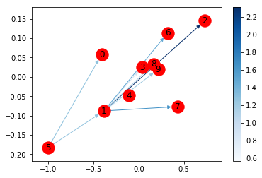

```python
dag = DAG(10, noise=.05) # We generated a directed acyclic graph with 10 vertices and .5 noise
data = dag.generate_data(1000) # How many data points are generated
plot_dag(dag) # The real underlying causal graph
```

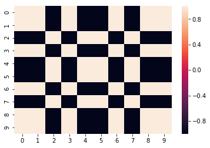

```python
sns.heatmap(np.cov(data.T)) # Correlation Matrix
```

A first approach to find partial autocorrelations is just computing the inverse of the correlation matrix:

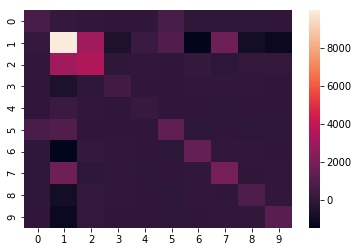

```python
sns.heatmap(np.linalg.inv((np.cov(data.T)))) #Partial correlation matrix:
```

Other approaches would be to use linear regression (OLS) for each variable:

```python
# Pick a target variable (y) by looking at the above plot.
# Let the rest of the data be potential predictors

def pick(d, i):
    return d[:, i], np.delete(d, i, 1)

y, X = pick(scale(data), 1)
```

```python
# Take a look at the results from OLS.
# 1. Are they reasonable?
# 2. Are there any spurious correlations?
print(sm.OLS(y, X).fit().summary())
```

```
                            OLS Regression Results
==============================================================================
Dep. Variable:                      y   R-squared:                       1.000
Model:                            OLS   Adj. R-squared:                  1.000
Method:                 Least Squares   F-statistic:                 1.097e+06
Date:                Mon, 13 May 2019   Prob (F-statistic):               0.00
Time:                        13:01:36   Log-Likelihood:                 3184.6
No. Observations:                1000   AIC:                            -6351.
Df Residuals:                     991   BIC:                            -6307.
Df Model:                           9
Covariance Type:            nonrobust
==============================================================================
                 coef    std err          t      P>|t|      [0.025      0.975]
------------------------------------------------------------------------------
x1            -0.0114      0.009     -1.319      0.188      -0.028       0.006
x2            -0.3138      0.016    -19.587      0.000      -0.345      -0.282
x3             0.0573      0.007      8.102      0.000       0.043       0.071
x4            -0.0286      0.005     -6.195      0.000      -0.038      -0.020
x5            -0.0913      0.012     -7.934      0.000      -0.114      -0.069
x6             0.1460      0.011     12.786      0.000       0.124       0.168
x7            -0.1744      0.013    -13.447      0.000      -0.200      -0.149
x8             0.0900      0.009     10.276      0.000       0.073       0.107
x9             0.1103      0.010     10.799      0.000       0.090       0.130
==============================================================================
Omnibus:                        0.701   Durbin-Watson:                   1.930
Prob(Omnibus):                  0.704   Jarque-Bera (JB):                0.572
Skew:                           0.003   Prob(JB):                        0.751
Kurtosis:                       3.117   Cond. No.                         166.
==============================================================================

Warnings:
[1] Standard Errors assume that the covariance matrix of the errors is correctly specified.
```

However, given the error term, spurious correlations seem to appear. Hence we will use a methodology which penalizes lack of predictive power which is Lasso.

```python
def recover_adj(data, precision):
    adj_list = []
    for i in range(10):
        y, X = pick(scale(data), i)
        clf = Lasso(alpha = precision)
        clf.fit(X, y, check_input=True)
        neighbours =[]
        for j, e in enumerate(clf.coef_):
            if e != 0:
                if j > i:
                    neighbours.append(j+1)
                else:
                    neighbours.append(j)
        adj_list.append([i,neighbours])
    return adj_list
```

```python
recover_adj(data, 0.1) # Pass the function the data and a precision for Lasso and it returns the adjacency matrix
```

```
[[0, [0, 2, 5]],
 [1, [0, 1, 3, 4, 5, 6, 7]],
 [2, [0, 1, 7]],
 [3, [1, 7, 9]],
 [4, [1, 7]],
 [5, [0, 1]],
 [6, [1, 2, 6]],
 [7, [1, 2]],
 [8, [0, 1, 2]],
 [9, [1, 2, 7]]]
```

However we want to visualize the results hence we will apply the following functions:

```python
def fill_diag(arr):
    """ Fills out an array with ones in the diagonal """
    P = arr.shape[0]
    a = np.ones((P,P))
    for i,c in enumerate(arr):
        a[i] = np.insert(c, i, 1)
    return a

def symmetrize(a, union):
    """ Makes adjacency matrix symmetric """
    c = (np.tril(a).T + np.triu(a))
    m = (c + c.T)

    # union or intersection
    if union:
        return m.astype(bool).astype(int)
    else:
        return (m >= 2).astype(int)

def coefs_to_adjacency(a, union = True):
    """ Converts a 2D numpy array of coefficients into adjacency matrix

    union: To use the union of the non-zero coefficients of symmetric
    regressions. If False, uses the intersection.
    """
    return symmetrize(fill_diag(a), union)

def score_adjacency(predicted_adj, dag):
    """ Score predicted adjacency matrix

    Calculates precision and recall scores of an adjacency matrix
    against the truth of the original DAG instance.
    """
    preds = predicted_adj.reshape(-1)
    y = np.abs(dag.adjacency).astype(bool).astype(int).reshape(-1)
    return precision_score(y, preds), recall_score(y, preds)

def regress(data, alpha, fn):
    """ Runs local regressions for each feature in dataset """
    d = [pick(data, i) for i in range(data.shape[1])]
    coefs = [fn(y,X,alpha) for y,X in d]
    return np.array(coefs)
```

```python
def fn_a(y, X, alpha):
    """Runs Lasso regression to each feature in dataset and returns its neighbours"""
    clf = Lasso(alpha = alpha)
    clf.fit(X, y, check_input=True)
    neighbours =[]
    for j, e in enumerate(clf.coef_):
        if e != 0:
            neighbours.append(1)
        else:
            neighbours.append(0)
    return neighbours
```

As we can see, using Lasso we obtain a pretty good recall and a not so great precision.

```python
# Test your regression function and compare

coefs = regress(data, .25, fn_a)
predicted_adj = coefs_to_adjacency(coefs, True)

score_adjacency(predicted_adj, dag)
```

```
(0.3125, 1.0)
```

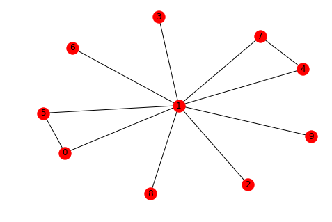

```python
# Visualize your predicted adjacency matrix
G = nx.from_numpy_array(predicted_adj)
nx.draw(G, with_labels=True)
```

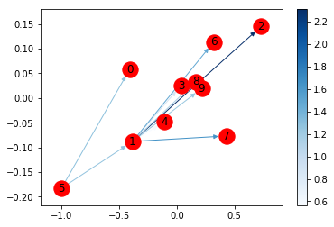

```python
plot_dag(dag)
```

In the end, we manage to uncover many of the relations between the nodes, however we still need to know the directions of the arrows, this can be done using the PC algorithm.

# Discovering the directions of Causality:

In this part, we will try to discover the causal relationships in real world data, concretely on the mathmarks dataset. The dataset contains the grades for different students in five subjects.

```python
%%R
data(mathmarks)
```

```python
%%R
head(mathmarks)
```

```
  mechanics vectors algebra analysis statistics
1        77      82      67       67         81
2        63      78      80       70         81
3        75      73      71       66         81
4        55      72      63       70         68
5        63      63      65       70         63
6        53      61      72       64         73
```

```python
%%R
summary(mathmarks)
```

```
   mechanics        vectors         algebra         analysis
 Min.   : 0.00   Min.   : 9.00   Min.   :15.00   Min.   : 9.00
 1st Qu.:30.00   1st Qu.:42.00   1st Qu.:45.00   1st Qu.:35.75
 Median :41.50   Median :51.00   Median :50.00   Median :49.00
 Mean   :38.95   Mean   :50.59   Mean   :50.60   Mean   :46.68
 3rd Qu.:49.25   3rd Qu.:60.00   3rd Qu.:57.25   3rd Qu.:57.00
 Max.   :77.00   Max.   :82.00   Max.   :80.00   Max.   :70.00
   statistics
 Min.   : 9.00
 1st Qu.:31.00
 Median :40.00
 Mean   :42.31
 3rd Qu.:51.50
 Max.   :81.00
```

```python
%%R
suffStat <- list(C=cor(mathmarks), n=nrow(mathmarks))
suffStat
```

```
$C
           mechanics   vectors   algebra  analysis statistics
mechanics  1.0000000 0.5534052 0.5467511 0.4093920  0.3890993
vectors    0.5534052 1.0000000 0.6096447 0.4850813  0.4364487
algebra    0.5467511 0.6096447 1.0000000 0.7108059  0.6647357
analysis   0.4093920 0.4850813 0.7108059 1.0000000  0.6071743
statistics 0.3890993 0.4364487 0.6647357 0.6071743  1.0000000

$n
[1] 88
```

At first sight, it seems that many of the subjects are quite correlated, which makes sense since they belong to the same degree.

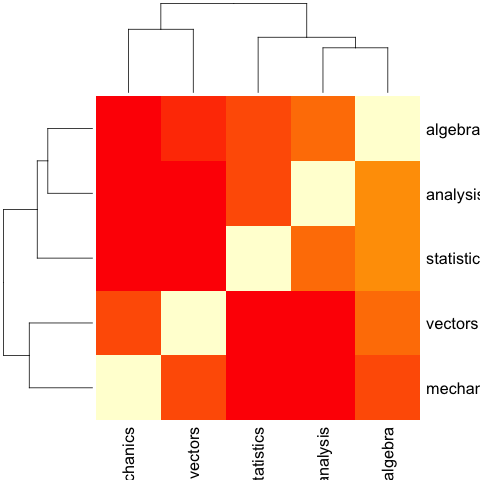

```python
%%R
heatmap(suffStat$C)
```

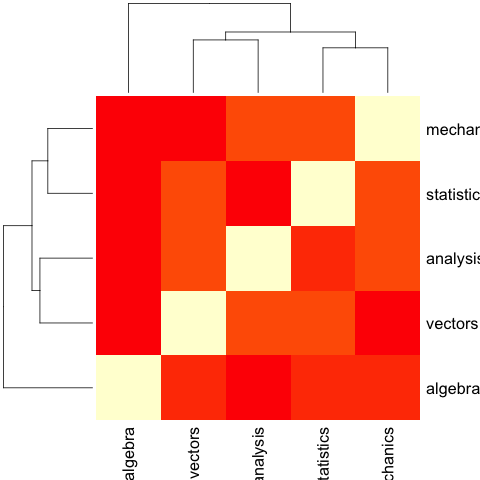

```python
%%R
heatmap(solve(suffStat$C)) #As before, we try to first discover the partial autocorrelations using
                            #the inverse of the correlation matrix.
```

The heatmap shows a possible relation between vectors and mechanics and algebra but is not that easy to interpret. Nonetheless, we could derive a graph representation for this data which would look like this:

[figure not shown]

**Without taking into consideration the arrows.**

Therefore, now, in order to discover the relationship between the variables we can apply the PC algorithm: The algorithm basically begins with a fully connected graph and remove edges using the conditional independence relations. In fact, it also finds the directions of the arrows by trying the same rules.

```python
%%R
pc.fit <- pc(suffStat, indepTest=gaussCItest, p=ncol(mathmarks),alpha=0.005)
```

```python
%%R
pc.fit
```

```
Object of class 'pcAlgo', from Call:
pc(suffStat = suffStat, indepTest = gaussCItest, alpha = 0.005,
    p = ncol(mathmarks))
Number of undirected edges:  1
Number of directed edges:    3
Total number of edges:       4
```

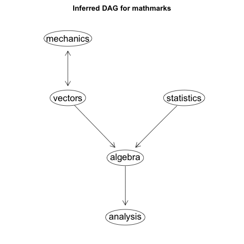

```python
%%R
library(Rgraphviz)
plot(pc.fit,labels=colnames(mathmarks),main="Inferred DAG for mathmarks")
```

In the end, the following graph is obtained. As we can see, it seems that algebra is the main source for the subject analyis whereas it is a combination between statistics and vectors. Nevertheless, the relation between mechanics and vectors coulnd't be obtained just with the test, hence in this case we should run some experimentation.

# Non-Linear and Non-Gaussian Models:

[figure not shown]

## Lingam

Paper: Shimizu et al. **LiNGAM: Non-Gaussian methods for estimating causal structures**, 2006. http://www.ar.sanken.osaka-u.ac.jp/~sshimizu/papers/Shimizu13BHMK.pdf

Lingam is an algorithm that allows us to identify causal relations when those are linear and non-Gaussian. Similarly to the pc-algorithm it tries to identify those relations by identifying conditional independences, however, it does not use any parametrization in the underlying to test it. What it does is model the data as the weighted sum of independent non-gaussian distributions, where those weights are estimated using maximum likelihood. Once the underlying structure is know, it uses the rules of the DAG to identify the directions of the graphs.

```python
%%R
set.seed(123)
n <- 1000
data <- NULL
x1 <- 2*runif(n) - 1 #uniform distribution
x2 <- x1 + runif(n)-0.5 #uniform distribution
x3 <- x1 + 0.6*rexp(n) #exponential distribution
x4 <- ifelse(rbinom(n, size = 1, prob = 0.6) > 0, 0, rpois(n, lambda = 3)) #zero inflated distribution
x5 <- 3*x3 + 2*x4 + 2*runif(n) # uniform distribution
x6 <- 10*runif(n) - 5 #uniform distribution
x7 <- 1.5*x6 + 5*rexp(n) #exponential distribution
x8 <- 2*x7 + 1.5*rchisq(n , df = 2) #chi-squared distribution
x9 <- x7 + 4*rchisq(n, df = 6)
data <- cbind(x1,x2,x3,x4,x5,x6,x7,x8,x9)
```

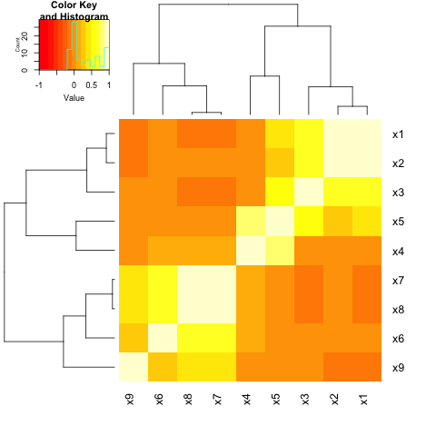

```python
%%R
heatmap.2(cor(data), trace = "none")
```

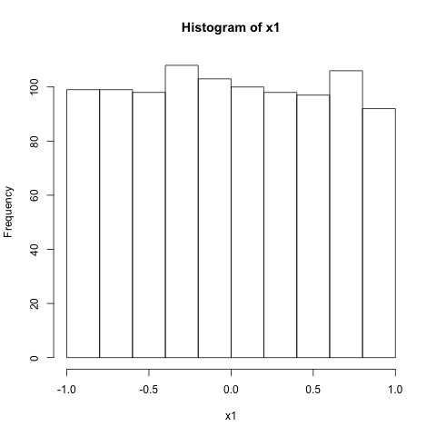

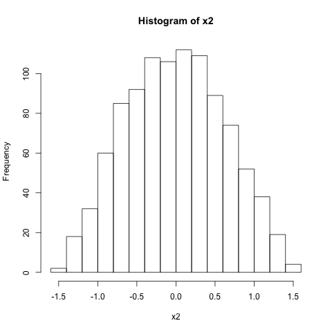

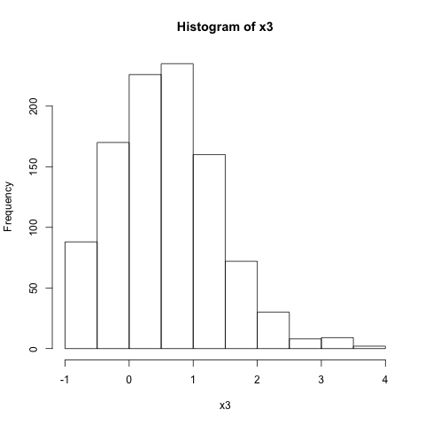

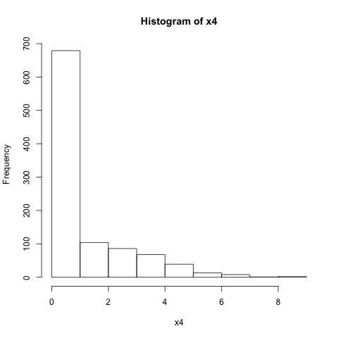

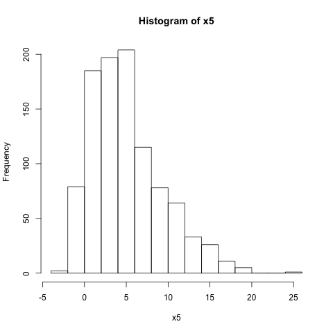

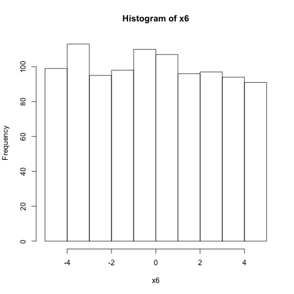

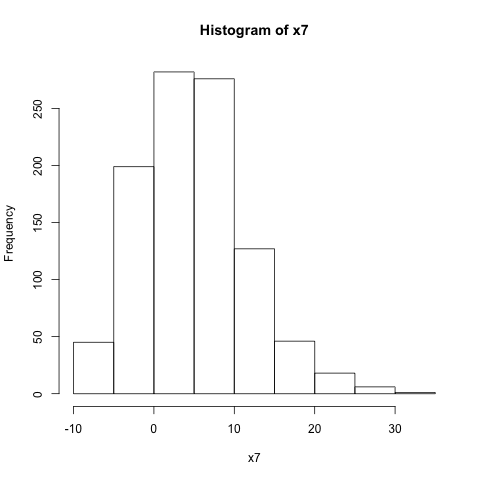

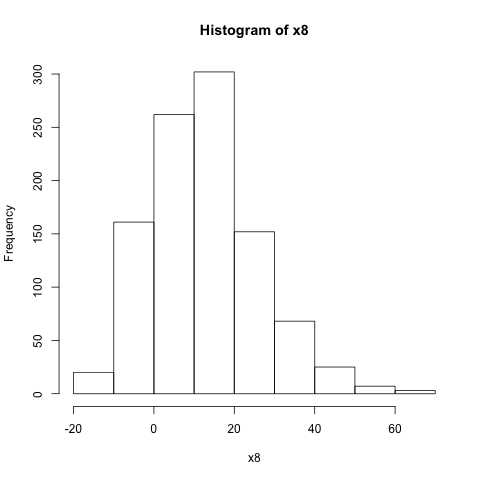

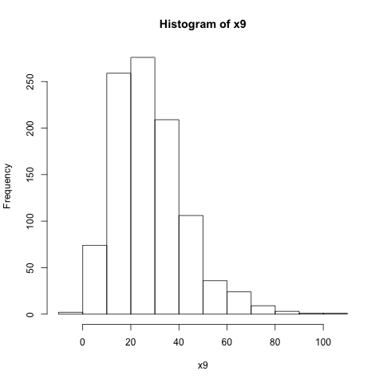

```python
%%R
hist(x1)
hist(x2)
hist(x3)
hist(x4)
hist(x5)
hist(x6)
hist(x7)
hist(x8)
hist(x9)
```

```python
%%R
set.seed(123)
result <- as(lingam(data, verbose = TRUE),  "amat")
```

```
Performing row permutation, nzdiag*() ...
  (Using the Hungarian algorithm.): Done!
Performing permutation for causal order...
  (Using pruning algorithm.): Done!
             [,1]        [,2]        [,3]        [,4]         [,5]         [,6]
 [1,]  0.00000000  0.04018604  0.05835210  0.04074836 -0.015066779  0.001659481
 [2,]  0.93501032  0.00000000  0.05116511  0.02289843 -0.006583349  0.002932227
 [3,]  1.09652993 -0.10190983  0.00000000  0.01788560 -0.007184770 -0.006876210
 [4,]  0.42630235 -0.71741430  0.29159378  0.00000000 -0.096393402  0.014505247
 [5,] -0.06732433  0.06421446  3.01062477  2.00623501  0.000000000 -0.002842459
 [6,]  0.09707384 -0.15100663 -0.60617422 -0.29801729  0.171358840  0.000000000
 [7,]  0.77407351 -0.36013768 -0.83788197 -0.01488210  0.078373403  1.444124962
 [8,] -0.24476164  0.56114254  0.29095285  0.11737375 -0.105148671 -0.029123905
 [9,] -0.98930728 -0.62481027 -6.98208009 -3.90920672  2.522063159 -0.935356278
              [,7]          [,8]          [,9]
 [1,]  0.012875574 -0.0088201259  6.768348e-05
 [2,]  0.004758132 -0.0025052322  7.167873e-04
 [3,]  0.003597471  0.0004046827  2.804068e-04
 [4,] -0.051572755  0.0434405704 -2.590086e-02
 [5,] -0.004483104  0.0032289301 -9.330203e-04
 [6,] -0.001533056 -0.0064602647 -1.986105e-03
 [7,]  0.000000000  0.0522488677 -3.268202e-02
 [8,]  1.991858022  0.0000000000 -2.404550e-03
 [9,]  1.325662946  0.0442071848  0.000000e+00
Causal B nicely triangular. No problems to report here.
Pruning the network connections...
Done!
```

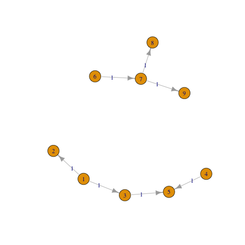

```python
%%R
library(igraph)
ge1<- graph.adjacency(adjmatrix=result,mode="directed",weighted=TRUE,diag=FALSE)
plot(ge1,edge.label=round(E(ge1)$weight,3))
```

## KPCalg (Kernel Based PC algorithm):

Paper: GRETTON et al. **A Kernel Statistical Test of Independence**, 2017 https://papers.nips.cc/paper/3201-a-kernel-statistical-test-of-independence.pdf

The Kernel Based PC algorithm is completely non-parametric. It does not assume neither the distribution of the data nor the way the data is related. To do so, it tests independence based on the kernel distribution of the data using the Hilbert-Schmidt independence criterion.

```python
%%R
set.seed(123)
n <- 1000
data <- NULL
x1 <- 2*runif(n) - 1 #uniform distribution
x2 <- sin(x1) + runif(n)-0.5 #uniform distribution
x3 <- x1^3 + 0.6*rexp(n) #exponential distribution
x4 <- ifelse(rbinom(n, size = 1, prob = 0.6) > 0, 0, rpois(n, lambda = 3)) #zero inflated distribution
x5 <- 3*cos(x3) + 2*x4 + 2*runif(n) # uniform distribution
x6 <- 10*runif(n) - 5 #uniform distribution
x7 <- 1.5*x6^2 + 5*rexp(n) #exponential distribution
x8 <- 2*x7^3 + 1.5*rchisq(n , df = 2) #chi-squared distribution
x9 <- log(x7) + 4*rchisq(n, df = 6)
data <- cbind(x1,x2,x3,x4,x5,x6,x7,x8,x9)
```

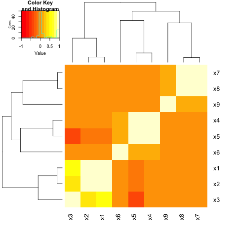

```python
%%R
heatmap.2(cor(data), trace = "none")
```

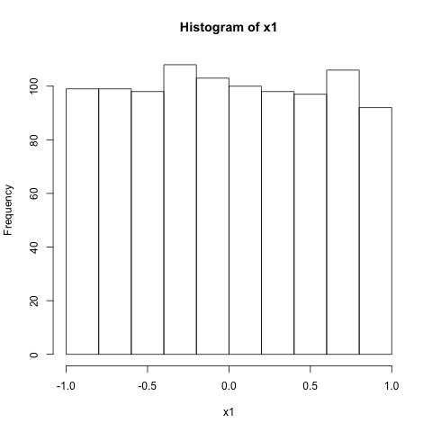

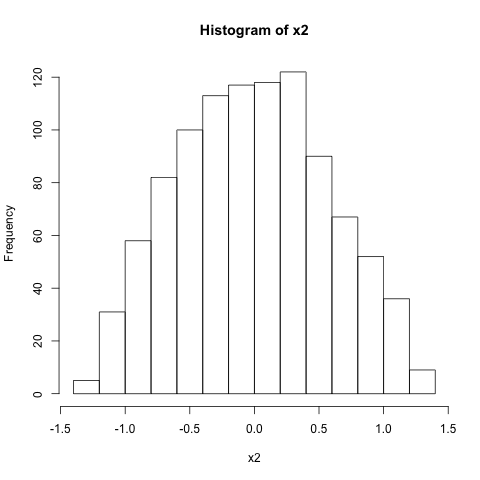

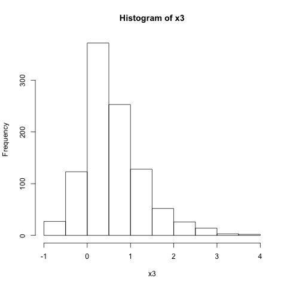

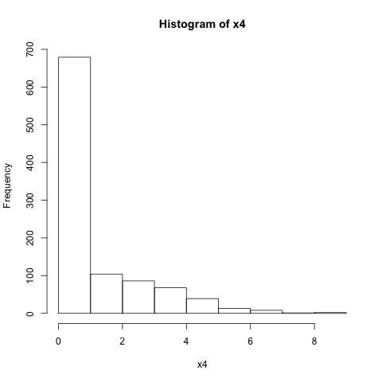

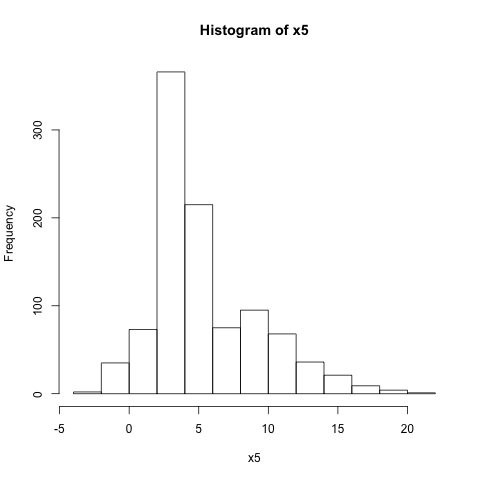

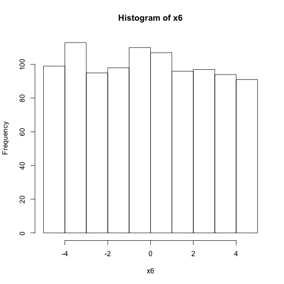

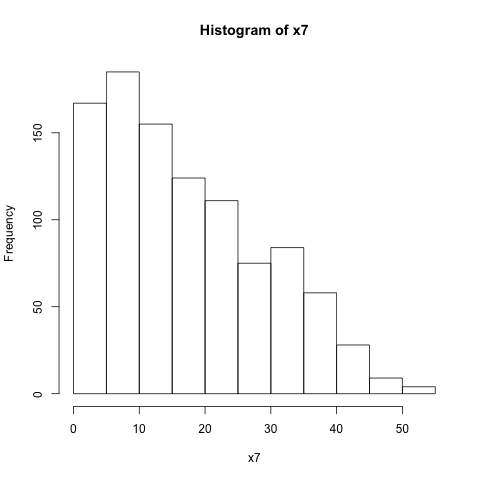

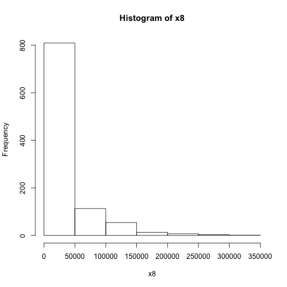

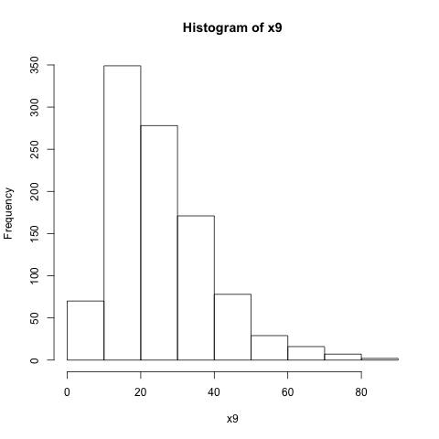

```python
%%R
hist(x1)
hist(x2)
hist(x3)
hist(x4)
hist(x5)
hist(x6)
hist(x7)
hist(x8)
hist(x9)
```

```python
%%R
kpc.fit <- kpc(suffStat = list(data = data, ic.method = "hsic.perm"), #hsic permutation criterion
              indepTest = kernelCItest,
              alpha = 0.05,
              labels=colnames(data),
              verbose = TRUE)
```

```
Order=0; remaining edges:72
x= 1  y= 2  S=  : pval = 0.00990099
x= 1  y= 3  S=  : pval = 0.00990099
x= 1  y= 4  S=  : pval = 0.4158416
x= 1  y= 5  S=  : pval = 0.00990099
x= 1  y= 6  S=  : pval = 0.4752475
x= 1  y= 7  S=  : pval = 0.1089109
x= 1  y= 8  S=  : pval = 0.3762376
x= 1  y= 9  S=  : pval = 0.6435644
x= 2  y= 1  S=  : pval = 0.00990099
x= 2  y= 3  S=  : pval = 0.00990099
x= 2  y= 4  S=  : pval = 0.1089109
x= 2  y= 5  S=  : pval = 0.00990099
x= 2  y= 6  S=  : pval = 0.6831683
x= 2  y= 7  S=  : pval = 0.1287129
x= 2  y= 8  S=  : pval = 0.5940594
x= 2  y= 9  S=  : pval = 0.7920792
x= 3  y= 1  S=  : pval = 0.00990099
x= 3  y= 2  S=  : pval = 0.00990099
x= 3  y= 4  S=  : pval = 0.6732673
x= 3  y= 5  S=  : pval = 0.00990099
x= 3  y= 6  S=  : pval = 0.3069307
x= 3  y= 7  S=  : pval = 0.4158416
x= 3  y= 8  S=  : pval = 0.5643564
x= 3  y= 9  S=  : pval = 0.5742574
x= 4  y= 5  S=  : pval = 0.00990099
x= 4  y= 6  S=  : pval = 0.9108911
x= 4  y= 7  S=  : pval = 0.9108911
x= 4  y= 8  S=  : pval = 0.4752475
x= 4  y= 9  S=  : pval = 0.5841584
x= 5  y= 1  S=  : pval = 0.00990099
x= 5  y= 2  S=  : pval = 0.00990099
x= 5  y= 3  S=  : pval = 0.00990099
x= 5  y= 4  S=  : pval = 0.00990099
x= 5  y= 6  S=  : pval = 0.4455446
x= 5  y= 7  S=  : pval = 0.6732673
x= 5  y= 8  S=  : pval = 0.5346535
x= 5  y= 9  S=  : pval = 0.1584158
x= 6  y= 7  S=  : pval = 0.00990099
x= 6  y= 8  S=  : pval = 0.00990099
```

[output cut: 70 more lines]

```
V:  7 . Size of neighbourhood of V:  2
Nbhd of V:  6 8
Reject orientation 6 8 -> 7 , as 7 cannot be regressed to independence on its parents  and subset 6 8 .
Nbhd of V:  6 8
7 can be regressed to independence on its parents  and subset 6 .
W:  6
Nbhd of W:  7 8
6 cannot be regressed to independence on its parents  and subset 7 8 .
6 cannot be regressed to independence on its parents  and subset 7 .
Accept orientation 6 -> 7 .

Rule 2: Chain  6 -> 7 -> 8 : 6 -> 8
Reject orientation 8 -> 7 , as 7 cannot be regressed to independence on its parents 6 and subset 8 .
V:  8 . Size of neighbourhood of V:  0
V:  9 . Size of neighbourhood of V:  0
```

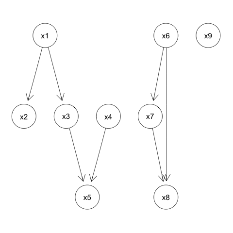

```python
%%R
plot(kpc.fit@graph, attrs=list(node=list(fontsize=5)))
```

```python
%%R
kpc.fit <- kpc(suffStat = list(data = data, ic.method = "hsic.gamma"), #hsic with gamma distribution
              indepTest = kernelCItest,
              alpha = 0.05,
              labels=colnames(data),
              verbose = TRUE)
```

```
Order=0; remaining edges:72
x= 1  y= 2  S=  : pval = 0
x= 1  y= 3  S=  : pval = 0
x= 1  y= 4  S=  : pval = 0.4240978
x= 1  y= 5  S=  : pval = 1.11311e-12
x= 1  y= 6  S=  : pval = 0.4881624
x= 1  y= 7  S=  : pval = 0.1164232
x= 1  y= 8  S=  : pval = 1
x= 1  y= 9  S=  : pval = 0.6059281
x= 2  y= 1  S=  : pval = 0
x= 2  y= 3  S=  : pval = 0
x= 2  y= 4  S=  : pval = 0.08039067
x= 2  y= 5  S=  : pval = 5.750967e-08
x= 2  y= 6  S=  : pval = 0.6754728
x= 2  y= 7  S=  : pval = 0.1170755
x= 2  y= 8  S=  : pval = 1
x= 2  y= 9  S=  : pval = 0.8425915
x= 3  y= 1  S=  : pval = 0
x= 3  y= 2  S=  : pval = 0
x= 3  y= 4  S=  : pval = 0.6332326
x= 3  y= 5  S=  : pval = 0
x= 3  y= 6  S=  : pval = 0.4104755
x= 3  y= 7  S=  : pval = 0.4169115
x= 3  y= 8  S=  : pval = 1
x= 3  y= 9  S=  : pval = 0.5862234
x= 4  y= 5  S=  : pval = 0
x= 4  y= 6  S=  : pval = 0.8847402
x= 4  y= 7  S=  : pval = 0.9243573
x= 4  y= 8  S=  : pval = 1
x= 4  y= 9  S=  : pval = 0.609559
x= 5  y= 1  S=  : pval = 1.11311e-12
x= 5  y= 2  S=  : pval = 5.750967e-08
x= 5  y= 3  S=  : pval = 0
x= 5  y= 4  S=  : pval = 0
x= 5  y= 6  S=  : pval = 0.3806237
x= 5  y= 7  S=  : pval = 0.7100504
x= 5  y= 8  S=  : pval = 1
x= 5  y= 9  S=  : pval = 0.1386315
x= 6  y= 7  S=  : pval = 0
x= 6  y= 8  S=  : pval = 1
```

[output cut: 43 more lines]

```
Accept orientation 1 -> 3 .
V:  4 . Size of neighbourhood of V:  0
V:  5 . Size of neighbourhood of V:  0
V:  6 . Size of neighbourhood of V:  1
Nbhd of V:  7
Reject orientation 7 -> 6 , as 6 cannot be regressed to independence on its parents  and subset 7 .
V:  7 . Size of neighbourhood of V:  1
Nbhd of V:  6
7 can be regressed to independence on its parents  and subset 6 .
W:  6
Nbhd of W:  7
6 cannot be regressed to independence on its parents  and subset 7 .
Accept orientation 6 -> 7 .
V:  8 . Size of neighbourhood of V:  0
V:  9 . Size of neighbourhood of V:  0
```

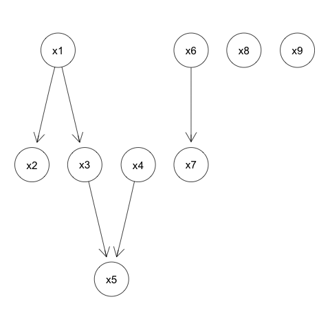

```python
%%R
plot(kpc.fit@graph, attrs=list(node=list(fontsize=5)))
```

```python
%%R
kpc.fit <- kpc(suffStat = list(data = data, ic.method = "dcc.perm"), #distance covariance criterion
              indepTest = kernelCItest,
              alpha = 0.05,
              labels=colnames(data),
              verbose = TRUE)
```

```
Order=0; remaining edges:72
x= 1  y= 2  S=  : pval = 0.00990099
x= 1  y= 3  S=  : pval = 0.00990099
x= 1  y= 4  S=  : pval = 0.2970297
x= 1  y= 5  S=  : pval = 0.00990099
x= 1  y= 6  S=  : pval = 0.1881188
x= 1  y= 7  S=  : pval = 0.6039604
x= 1  y= 8  S=  : pval = 0.4950495
x= 1  y= 9  S=  : pval = 0.1188119
x= 2  y= 1  S=  : pval = 0.00990099
x= 2  y= 3  S=  : pval = 0.00990099
x= 2  y= 4  S=  : pval = 0.1683168
x= 2  y= 5  S=  : pval = 0.00990099
x= 2  y= 6  S=  : pval = 0.6534653
x= 2  y= 7  S=  : pval = 0.2574257
x= 2  y= 8  S=  : pval = 0.3267327
x= 2  y= 9  S=  : pval = 0.1188119
x= 3  y= 1  S=  : pval = 0.00990099
x= 3  y= 2  S=  : pval = 0.00990099
x= 3  y= 4  S=  : pval = 0.7722772
x= 3  y= 5  S=  : pval = 0.00990099
x= 3  y= 6  S=  : pval = 0.4752475
x= 3  y= 7  S=  : pval = 0.4950495
x= 3  y= 8  S=  : pval = 0.3762376
x= 3  y= 9  S=  : pval = 0.5346535
x= 4  y= 5  S=  : pval = 0.00990099
x= 4  y= 6  S=  : pval = 0.07920792
x= 4  y= 7  S=  : pval = 0.2970297
x= 4  y= 8  S=  : pval = 0.4752475
x= 4  y= 9  S=  : pval = 0.8019802
x= 5  y= 1  S=  : pval = 0.00990099
x= 5  y= 2  S=  : pval = 0.00990099
x= 5  y= 3  S=  : pval = 0.00990099
x= 5  y= 4  S=  : pval = 0.00990099
x= 5  y= 6  S=  : pval = 0.01980198
x= 5  y= 7  S=  : pval = 0.06930693
x= 5  y= 8  S=  : pval = 0.2574257
x= 5  y= 9  S=  : pval = 0.7227723
x= 6  y= 5  S=  : pval = 0.02970297
x= 6  y= 7  S=  : pval = 0.00990099
```

[output cut: 93 more lines]

```
V:  7 . Size of neighbourhood of V:  2
Nbhd of V:  6 8
Reject orientation 6 8 -> 7 , as 7 cannot be regressed to independence on its parents  and subset 6 8 .
Nbhd of V:  6 8
7 can be regressed to independence on its parents  and subset 6 .
W:  6
Nbhd of W:  7 8
6 cannot be regressed to independence on its parents  and subset 7 8 .
6 cannot be regressed to independence on its parents  and subset 7 .
Accept orientation 6 -> 7 .

Rule 2: Chain  6 -> 7 -> 8 : 6 -> 8
Reject orientation 8 -> 7 , as 7 cannot be regressed to independence on its parents 6 and subset 8 .
V:  8 . Size of neighbourhood of V:  0
V:  9 . Size of neighbourhood of V:  0
```

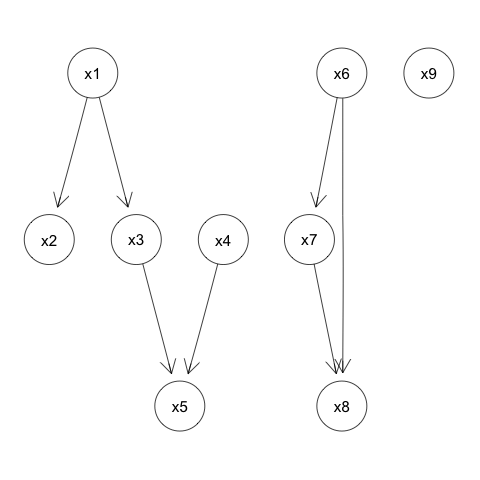

```python
%%R
plot(kpc.fit@graph, attrs=list(node=list(fontsize=5)))
```

# Conclusion: